# Figure 4.2

### 전처리

```r
popgrowth_df <- US_census %>%
  left_join(US_regions) %>%                         # US_census 기준으로 left_join
  group_by(region, division, state) %>%             # 그룹화할 컬럼 선택
  summarise(pop2000 = sum(pop2000, na.rm = T),      # 그룹화된 컬럼들의 집계값 설정
            pop2010 = sum(pop2010, na.rm = T),
            popgrowth = (pop2010 - pop2000)/pop2000,
            area = sum(area)) %>%
  arrange(popgrowth) %>%                            # 해당 컬럼 기준으로 오름차순 정렬
  ungroup() %>%                                     # 그룹화 해제
  mutate(state = factor(state, levels=state),       # 팩터로 변환, level 지정
         region = factor(region, levels=c('West','South','Midwest','Northeast')))
popgrowth_df
```

```
#> # A tibble: 51 × 7
#>    region    division           state          pop2000  pop2010 popgrowth   area
#>    <fct>     <chr>              <fct>            <int>    <int>     <dbl>  <dbl>
#>  1 Midwest   East North Central Michigan       9938444  9883640  -0.00551 56539.
#>  2 Northeast New England        Rhode Island   1048319  1052567   0.00405  1034.
#>  3 South     West South Central Louisiana      4468976  4533372   0.0144  43204.
#>  4 Midwest   East North Central Ohio          11353140 11536504   0.0162  40861.
#>  5 Northeast Middle Atlantic    New York      18976457 19378102   0.0212  47126.
#>  6 South     South Atlantic     West Virginia  1808344  1852994   0.0247  24038.
#>  7 Northeast New England        Vermont         608827   625741   0.0278   9217.
#>  8 Northeast New England        Massachusetts  6349097  6547629   0.0313   7800.
#>  9 Midwest   East North Central Illinois      12419293 12830632   0.0331  55519.
#> 10 Northeast Middle Atlantic    Pennsylvania  12281054 12702379   0.0343  44743.
#> # … with 41 more rows
```

```r
### 4개 지방의 색 지정
region_colors <- c('#E69F00','#56B4E9','#009E73','#F0E442')
region_colors
```

```
#> [1] "#E69F00" "#56B4E9" "#009E73" "#F0E442"
```

### Figure 4.2

- 사용 데이터셋 : popgrowth_df
- x=state, y=100*popgrowth
- fill : region별
- geom_col (막대 그래프)
- scale_y_continuous
  - 이름 : ‘population growth, 2000 to 2010’
  - 범위 : 0 ~ 0 : 더욱 직관적인 그래프 표현 가능
  - 라벨 : 백분율 형식
- scale_fill_manual
  - fill 옵션 색상 : region_colors
- coord_flip() : x축, y축 체인지 → 세로방향 긴 막대를 가로방향으로 짧게 표시
- 테마 : 밝게
- 테마 옵션
  - 그래프 패널의 테두리 제거
  - y축 그리드 제거
  - y축 레이블 제거
  - y축 눈금선 제거
  - y축 폰트 크기 설정
  - 그래프상의 범례 위치 조정
  - 범례 배경 색상 설정

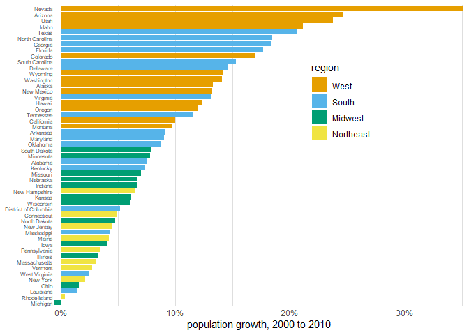

```r
ggplot(popgrowth_df, aes(x=state, y=100*popgrowth, fill=region)) +
  geom_col() +
  scale_y_continuous(name = 'population growth, 2000 to 2010',
                     labels = scales::percent_format(scale=1),
                     expand = c(0,0)) +
  scale_fill_manual(values = region_colors) +
  coord_flip() +
  theme_light() +
  theme(panel.border = element_blank(),
        panel.grid.major.y = element_blank(),
        axis.title.y = element_blank(),
        axis.ticks.length = unit(0, 'pt'),
        axis.text.y = element_text(size = 6),
        legend.position = c(.7, .68),
        legend.background = element_rect(fill = '#ffffffb0'))
```

## 예제

- 주민등록 인구 및 세대현황 Figure 4.2

### 데이터 불러오기, 파악

- 202202_주민등록인구및세대현황.csv

```r
kor_202202 <- read.csv('C:/Users/seong taek/Desktop/3-1 DataVisualize/data_visualize/202202_주민등록인구및세대현황.csv')

### 앞부분 훑어보기
kor_202202 %>%  head()
```

```
#>            행정구역 행정구역_코드 총인구수  세대수 세대당_인구 남자_인구수
#> 1       서울특별시     1100000000  9508451 4442586        2.14     4615823
#> 2 서울특별시 종로구    1111000000   144575   73763        1.96       70092
#> 3   서울특별시 중구    1114000000   122167   63644        1.92       59446
#> 4 서울특별시 용산구    1117000000   222413  111134        2.00      106881
#> 5 서울특별시 성동구    1120000000   285137  134286        2.12      138866
#> 6 서울특별시 광진구    1121500000   340494  168975        2.02      164226
#>   여자_인구수 남여_비율
#> 1     4892628      0.94
#> 2       74483      0.94
#> 3       62721      0.95
#> 4      115532      0.93
#> 5      146271      0.95
#> 6      176268      0.93
```

```r
### 차원 파악
kor_202202 %>% dim()
```

```
#> [1] 291   8
```

```r
### 컬럼 클래스(타입) 확인
kor_202202 %>% sapply(class)
```

```
#>      행정구역 행정구역_코드      총인구수        세대수   세대당_인구
#>   "character"     "numeric"     "numeric"     "numeric"     "numeric"
#>   남자_인구수   여자_인구수     남여_비율
#>     "numeric"     "numeric"     "numeric"
```

```r
### `행정구역_코드`를 numeric → character형식으로 변환
kor_202202$행정구역_코드 <- kor_202202$행정구역_코드 %>% format()
```

### 전처리

```r
# 행정구역 컬럼의 1,2번째 자리의 값을 지정해서 추출
# 행정구역_코드 컬럼의 3,4번째 자리의 값이 0이 아닌것만 추출
# 해당 열만 선택
# 해당 열 기준으로 오름차순 정렬
kor_202202_use <- kor_202202 %>%
  filter(substr(행정구역,1,2) %in% c('서울','대전','대구','부산')) %>%
  filter(substr(행정구역_코드,3,4) != '00') %>%
  select(행정구역, 총인구수) %>%
  arrange(총인구수)

kor_202202_use %>% head()
```

```
#>            행정구역 총인구수
#> 1   부산광역시 중구    40582
#> 2   대구광역시 중구    74710
#> 3   부산광역시 동구    88245
#> 4   부산광역시 서구   104618
#> 5 부산광역시 영도구   109991
#> 6   서울특별시 중구   122167
```

```r
### '시도' 컬럼 생성
kor_202202_use$시도 <- sapply(kor_202202_use$행정구역,
                            function(x) strsplit(x, " ")[[1]][1])

kor_202202_use$시도 %>% head()
```

```
#> [1] "부산광역시" "대구광역시" "부산광역시" "부산광역시" "부산광역시"
#> [6] "서울특별시"
```

```r
# factor 변환, level 지정
kor_202202_use$시도 <- factor(kor_202202_use$시도,
                            levels = c("서울특별시",
                                       "대전광역시",
                                       "대구광역시",
                                       "부산광역시"))

kor_202202_use$시도 %>% head()
```

```
#> [1] 부산광역시 대구광역시 부산광역시 부산광역시 부산광역시 서울특별시
#> Levels: 서울특별시 대전광역시 대구광역시 부산광역시
```

```r
kor_202202_use$시도 %>% summary()
```

```
#> 서울특별시 대전광역시 대구광역시 부산광역시
#>         25          5          8         16
```

```r
### 4개 지방의 색 지정
region_colors <- RColorBrewer::brewer.pal(4, "Set2")
```

### Figure 4.2

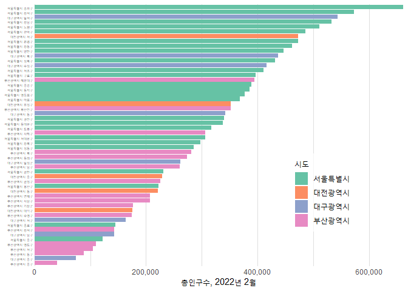

```r
ggplot(kor_202202_use, aes(x=reorder(행정구역, 총인구수), y=총인구수, fill=시도)) +
  geom_col() +
  scale_y_continuous(name = '총인구수, 2022년 2월',
                     labels = scales::comma,
                     expand = c(0,0)) +
  scale_fill_manual(values = region_colors) +
  coord_flip() +
  theme_light() +
  theme(panel.border = element_blank(),
        panel.grid.major.y = element_blank(),
        axis.title.y = element_blank(),
        axis.ticks.length = unit(0, 'pt'),
        axis.text.y = element_text(size = 5),
        legend.position = c(.78, .28),
        legend.background = element_rect(fill = '#ffffffb0'))
```

## Figure 4.8

### 전처리

```r
### 4개 지방의 색 지정 + 밝기조정 + 채도조정
region_colors <- c('#E69F00','#56B4E9','#009E73','#F0E442') %>% lighten(0.4) %>% desaturate(0.8)

region_colors
```

```
#> [1] "#D9CBBE" "#C3CDD6" "#AABCB3" "#F0EDD6"
```

```r
### 컬럼 추가 (region_highlight - NA)
popgrowth_df <- popgrowth_df %>%
  mutate(region_highlight = ifelse(state %in% c('Texas', 'Louisiana'),
                                   NA, region %>% paste()))

popgrowth_df %>% head()
```

```
#> # A tibble: 6 × 8
#>   region    division           state     pop2000 pop2010 popgro…¹   area regio…²
#>   <fct>     <chr>              <fct>       <int>   <int>    <dbl>  <dbl> <chr>
#> 1 Midwest   East North Central Michigan   9.94e6  9.88e6 -0.00551 56539. Midwest
#> 2 Northeast New England        Rhode Is…  1.05e6  1.05e6  0.00405  1034. Northe…
#> 3 South     West South Central Louisiana  4.47e6  4.53e6  0.0144  43204. <NA>
#> 4 Midwest   East North Central Ohio       1.14e7  1.15e7  0.0162  40861. Midwest
#> 5 Northeast Middle Atlantic    New York   1.90e7  1.94e7  0.0212  47126. Northe…
#> 6 South     South Atlantic     West Vir…  1.81e6  1.85e6  0.0247  24038. South
#> # … with abbreviated variable names ¹popgrowth, ²region_highlight
```

### Figure 4.8

- 사용 데이터셋 : popgrowth_df
- x=state, y=100*popgrowth
- fill : region_highlight별
- geom_col (막대 그래프)
- scale_y_continuous
  - 이름 : ‘population growth, 2000 to 2010’
  - 범위 : 0 ~ 0 : 더욱 직관적인 그래프 표현 가능
  - 라벨 : 백분율 형식
- scale_fill_manual
  - fill 옵션 색상 : region_colors
  - 그래프상 범례 레이블 지정
  - NA 값일 때 색상 지정
- coord_flip() : x축, y축 체인지 → 세로방향 긴 막대를 가로방향으로 짧게 표시
- 테마 : 밝게
- 테마 옵션
  - 그래프 패널의 테두리 제거
  - y축 그리드 제거
  - y축 레이블 제거
  - y축 눈금선 제거
  - y축 폰트 크기 설정
  - 그래프상의 범례 위치 조정
  - 범례 배경 색상 설정

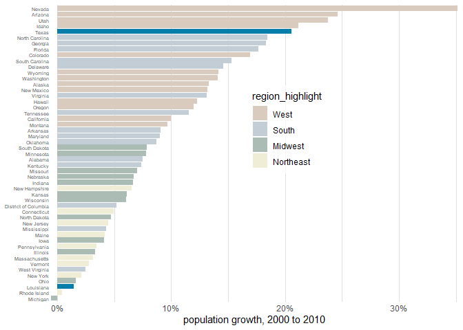

```r
ggplot(popgrowth_df, aes(x=state, y=100*popgrowth, fill=region_highlight)) +
  geom_col() +
  scale_y_continuous(name = 'population growth, 2000 to 2010',
                     labels = scales::percent_format(scale=1),
                     expand = c(0,0)) +
  scale_fill_manual(values = region_colors,
                    breaks = c("West", "South", "Midwest", "Northeast"),
                    na.value = "#56B4E9" %>% darken(0.3)) +
  coord_flip() +
  theme_light() +
  theme(panel.border = element_blank(),
        panel.grid.major.y = element_blank(),
        axis.title.y = element_blank(),
        axis.ticks.length = unit(0, 'pt'),
        axis.text.y = element_text(size = 5),
        legend.position = c(.58, .58),
        legend.background = element_rect(fill = '#ffffffb0')) # color =테두리색
```

## 예제2

### 대전광역시 강조하기

```r
### 컬러 지정시 대전 따로 지정
region_colors <- c('#E69F00','#56B4E9','#009E73','#F0E442') %>% lighten(0.4) %>% desaturate(0.8)

region_colors[2] <- "#56B4E9" %>% darken(0.3)

region_colors
```

```
#> [1] "#D9CBBE" "#077DAA" "#AABCB3" "#F0EDD6"
```

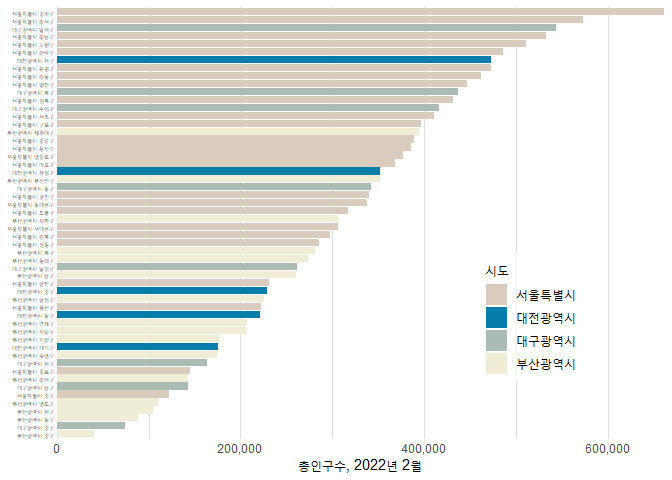

```r
ggplot(kor_202202_use, aes(x=reorder(행정구역, 총인구수), y=총인구수, fill=시도)) +
  geom_col() +
  scale_y_continuous(name = '총인구수, 2022년 2월',
                     labels = scales::comma,
                     expand = c(0,0)) +
  scale_fill_manual(values = region_colors) +
  coord_flip() +
  theme_light() +
  theme(panel.border = element_blank(),
        panel.grid.major.y = element_blank(),
        axis.title.y = element_blank(),
        axis.ticks.length = unit(0, 'pt'),
        axis.text.y = element_text(size = 5),
        legend.position = c(.78, .28),
        legend.background = element_rect(fill = '#ffffffb0'))
```